# rpnf

Sascha Herrmann sascha.herrmann.consulting@gmail.com

October 13, 2015

# Purpose of **rpnf**

**rpnf** is a collection of R functions for creating Point & Figure (P&F) charts and statistics for a given time series.

```
--------+---------------------------
   53.00|    X         X X
   52.00|    XO        XOXO+
   51.00|    XO        XOXO +
   50.00|X+X XOX     X XOXO  +
   49.00| OXOXOXO+   XOXO O   +
   48.00| OXOXOXO +  XOX  O    +   X <==
   47.00| OXOXO O  + XOX  OX    +  X
   46.00| OXO   OX  +XOX +OXO    + X
   45.00| OX   +OXOX XO + OXO    X+X
   44.00| OX  + OXOXOX +  O O  X XOX
   43.00| OX +  OXOXOX+     OX XOXOX
   42.00| OX+   O OXO       OXOXOXOX
   41.00| O       O         OXOXO OX
   40.00|                   OXOX  OX
   39.00|                   OXO   O
   38.00|                   OX
   37.00|                   OX
   36.00|                   OX
   35.00|                   O
--------+---------------------------
       Y|111111111111111111111111111
       Y|444444444555555555555555555
        |
       M|111111111000000000000000000
       M|000001222111133677788889999
        |
       D|011232001012202211212220023
       D|906316598558967947925671830
```

# Features of **rpnf**

**rpnf** allows the creation of P&F charts and statistics with the following features

- X/O status processing of time series with
  - configurable box size
  - configurable reversal
  - linear/logarithmic scales
- Determiniation of next X/O or reversal O/X points
- Buy/Sell status
- Buy/Sell signal detection, currently
  - Double Top/Bottom
  - Triple Top/Bottom
  - Bullish/Bearish signal
  - Bullish/Bearish catapult
  - etc.

# How to install **rpnf**

1. We are asuming you have R installed and working. If not please consult one of well written howto’s.
2. Go to the R console, or your favorite R-IDE (we recommend http://www.rstudio.com)
3. Install latest stable version of **rpnf** with

   ```
   install.packages("rpnf")
   ```

4. **rpnf** is now installed, and you can continue with the getting started section.

#### Getting the latest development version from Rforge

If you want to use (for a good reason) the latest development version from Rforge, then you can install it with:

```
install.packages("rpnf", repos="http://R-Forge.R-project.org")
```

# How to get started with **rpnf**

Once **rpnf** is installed you can start using it by loading the library:

```r
library(rpnf) # Load rpnf library
```

A typical workflow for using **rpnf** consists of three steps:

- Preparing some time series data
- Determining the P&F statistics for this time series
- Plotting the P&F chart for this time series

### Getting some data

**rpnf** has some sample data built in:

```r
data(DOW)   # Load some example data
```

You can have a look at these data with `str(DOW)` or `DOW`.

### Determining the P&F statistics

To determine the P&F statistics of a time series you use:

```r
pnfdata <- pnfprocessor(
  high=DOW$High,
  low=DOW$Low,
  date=DOW$Date,
  boxsize=1L,
  log=FALSE)
```

### Understanding the P&F statistics

The data.frame returned by `pnfprocessor(...)` is full of P&F statistics on the given time series. Every row consists of one observation on the time series, whereas columns have the following meaning:

- date : the date of the observation in the time series
- high : the high values of the time series at observation date
- low : the low values of the time series at observation date
- boxnumber : boxnumber (integer) of the current chart status
- column : current column (integer) in the P&F chart
- status.xo : factor containing the current X or O status
- nextX : threshold to reach in order to make an X. If latest status.xo is an O, then this is the reversal point.
- nextO : threshold to reach in order to make an O. If latest status.xo is an X, then this is the reversal point.
- status.bs : factor containing the current Buy/Sell status of this observation
- lastNextX : highest value of the previous X-column. Used for Buy/Sell detection.
- lastNextO : lowest value of the previous O-column. Used for Buy/Sell detection.
- signal.bs : current P&F buy or sell signal, such as Double Top, etc.

This data.frame can be used either to do some statistical analysis, or it can be used to generate plots.

### Generating P&F plots

Generating plots from a pnf data.frame can be achieved by:

```r
pnfplottxt(
  data = pnfdata,
  reversal = 3,
  boxsize = 1L,
  log = F)
```

```
## --------+---------------------------
##    53.00|    X         X X
##    52.00|    XO        XOXO+
##    51.00|    XO        XOXO +
##    50.00|X+X XOX     X XOXO  +
##    49.00| OXOXOXO+   XOXO O   +
##    48.00| OXOXOXO +  XOX  O    +   X <==
##    47.00| OXOXO O  + XOX  OX    +  X
##    46.00| OXO   OX  +XOX +OXO    + X
##    45.00| OX   +OXOX XO + OXO    X+X
##    44.00| OX  + OXOXOX +  O O  X XOX
##    43.00| OX +  OXOXOX+     OX XOXOX
##    42.00| OX+   O OXO       OXOXOXOX
##    41.00| O       O         OXOXO OX
##    40.00|                   OXOX  OX
##    39.00|                   OXO   O
##    38.00|                   OX
##    37.00|                   OX
##    36.00|                   OX
##    35.00|                   O
## --------+---------------------------
##        Y|222222222222222222222222222
##        Y|000000000000000000000000000
##        Y|111111111111111111111111111
##        Y|444444444555555555555555555
##        M|111111111000000000000000000
##        M|000001222111133677788889999
##        D|011232001012202211212220023
##        D|906316598558967947925671830
```

Alternatively you can plot a graphical chart with:

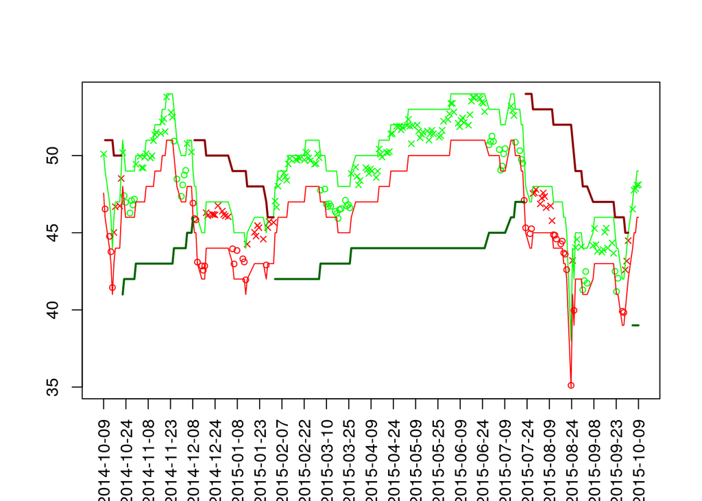

```r
pnfplot(
  data = pnfdata,
  reversal = 3,
  boxsize = 1L,
  log = F)
```

# Support

If you need commerical support feel free to contact Sascha Herrmann sascha.herrmann.consulting@gmail.com for an offer. You can also request a new feature development there.

For non-commerical support please refer to the [r-forge project page](http://r-forge.r-project.org/projects/rpnf/) and some online communities like [stackoverflow](http://stackoverflow.com/).

# Development roadmap

Our current focus is to develop a set of wrappers and extensions to **rpnf**, so that it gets easier to exploit the full functionality of **rpnf** for creating Bullish Percent, Relative Strenght Charts, and others.